# Electric Power Consumption - Exploratory

This file is *not* the assignment - this is my working draft of the components that will go into the final assignment submission.

We only care about two days worth of data. I thought it was a lot simpler to pull the data out from the unzipped text file using shell script, and then import the data.

But in keeping with the code I eventually wrote for the plot scripts, I'll just pull it in and reuse it that way.

```r
source(file = "LoadAndPrepInput.R")
```

Here is the codebook for the data:

1. Date: Date in format dd/mm/yyyy
2. Time: time in format hh:mm:ss
3. Global_active_power: household global minute-averaged active power (in kilowatt)
4. Global_reactive_power: household global minute-averaged reactive power (in kilowatt)￼￼￼￼￼￼￼￼￼￼￼
5. Voltage: minute-averaged voltage (in volt)
6. Global_intensity: household global minute-averaged current intensity (in ampere)
7. Sub_metering_1: energy sub-metering No. 1 (in watt-hour of active energy). It corresponds to the kitchen, containing mainly a dishwasher, an oven and a microwave (hot plates are not electric but gas powered).
8. Sub_metering_2: energy sub-metering No. 2 (in watt-hour of active energy). It corresponds to the laundry room, containing a washing-machine, a tumble-drier, a refrigerator and a light.
9. Sub_metering_3: energy sub-metering No. 3 (in watt-hour of active energy). It corresponds to an electric water-heater and an air-conditioner.

Finally we have something we can look at, let's start with the summary data

```r
summary(hpc)
```

```
##      Date               Time           Global_active_power
##  Length:2880        Length:2880        Min.   :0.22
##  Class :character   Class :character   1st Qu.:0.32
##  Mode  :character   Mode  :character   Median :1.06
##                                        Mean   :1.21
##                                        3rd Qu.:1.69
##                                        Max.   :7.48
##  Global_reactive_power    Voltage    Global_intensity Sub_metering_1
##  Min.   :0.000         Min.   :233   Min.   : 1.0     Min.   : 0.00
##  1st Qu.:0.000         1st Qu.:238   1st Qu.: 1.4     1st Qu.: 0.00
##  Median :0.104         Median :241   Median : 4.6     Median : 0.00
##  Mean   :0.101         Mean   :240   Mean   : 5.1     Mean   : 0.41
##  3rd Qu.:0.144         3rd Qu.:242   3rd Qu.: 7.0     3rd Qu.: 0.00
##  Max.   :0.500         Max.   :247   Max.   :32.0     Max.   :38.00
##  Sub_metering_2  Sub_metering_3    DateTime
##  Min.   :0.000   Min.   : 0.0   Min.   :2007-02-01 00:00:00
##  1st Qu.:0.000   1st Qu.: 0.0   1st Qu.:2007-02-01 11:59:45
##  Median :0.000   Median : 0.0   Median :2007-02-01 23:59:30
##  Mean   :0.258   Mean   : 8.5   Mean   :2007-02-01 23:59:30
##  3rd Qu.:0.000   3rd Qu.:17.0   3rd Qu.:2007-02-02 11:59:15
##  Max.   :2.000   Max.   :19.0   Max.   :2007-02-02 23:59:00
```

Now we can get to plotting something.

First one is power frequency histogram.

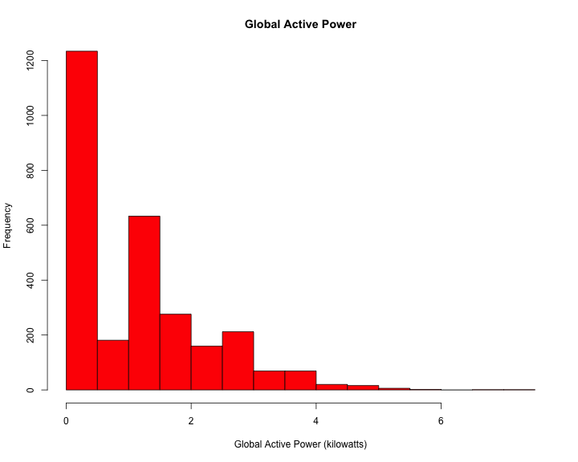

```r
hist(hpc$Global_active_power, xlab = "Global Active Power (kilowatts)", ylim = c(0,
    1200), col = "red", main = "Global Active Power")
```

Next one is global active power per day.

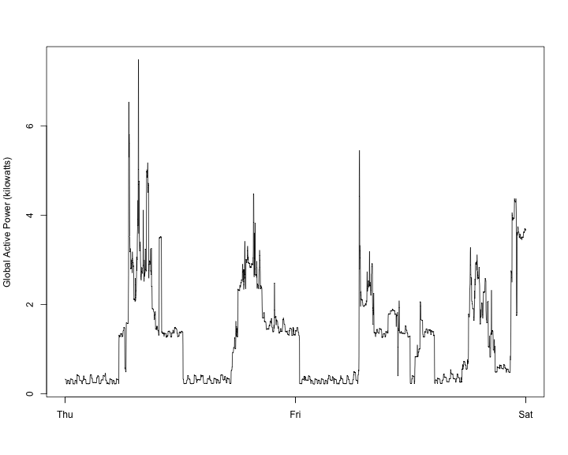

```r
# earlier experiment hpc$weekday <- weekdays(hpc$datetime,abbreviate=TRUE)
# hpc$weekday <- as.factor(hpc$weekday) powday <-
# aggregate(hpc$Global_active_power,by=list(hpc$weekday),sum)

with(hpc, plot(x = DateTime, y = Global_active_power, type = "l", xlab = "",
    ylab = "Global Active Power (kilowatts)"))
```

Next one is sub-metering levels per day, one line each.

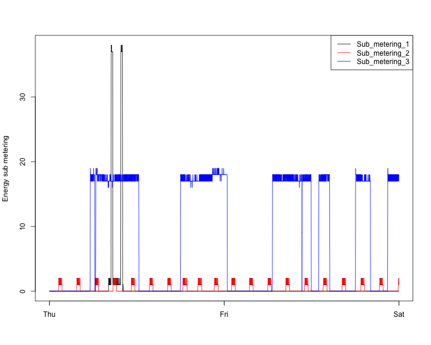

```r
with(hpc, plot(x = DateTime, y = Sub_metering_1, type = "l", xlab = "", ylab = "Energy sub metering"))
with(hpc, lines(x = DateTime, y = Sub_metering_2, col = "red"))
with(hpc, lines(x = DateTime, y = Sub_metering_3, type = "l", col = "blue"))
with(hpc, legend("topright", legend = c("Sub_metering_1", "Sub_metering_2",
    "Sub_metering_3"), col = c("black", "red", "blue"), lty = 1))
```

Last one is a 2x2 layout of: power per day, voltage per day sub-meters per day, reactive power per day

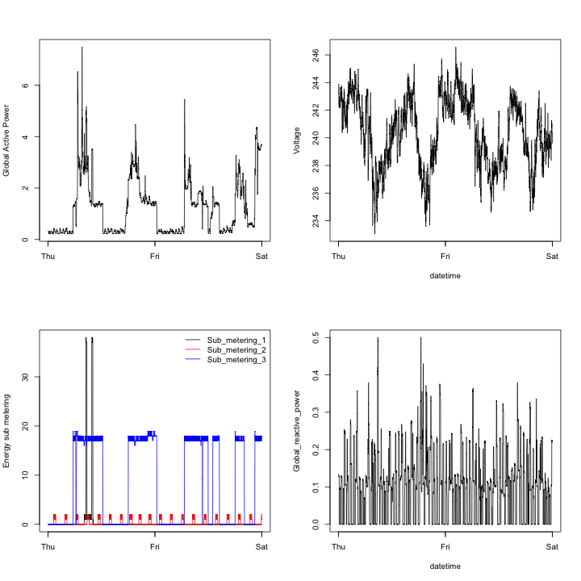

```r
par(mfrow = c(2, 2))
# TODO make a function to factor out out the common elements here for now
# just copy from previous graphs, global active power note this one is
# subtly different on the ylabel - no units declared now
with(hpc, plot(x = DateTime, y = Global_active_power, type = "l", xlab = "",
    ylab = "Global Active Power"))

# second graph also uses a simple xlabel, make sure its there
with(hpc, plot(x = DateTime, y = Voltage, type = "l", xlab = "datetime", ylab = "Voltage"))

# third graph is just sub-metering again (but no box around the legend)
with(hpc, plot(x = DateTime, y = Sub_metering_1, type = "l", xlab = "", ylab = "Energy sub metering"))
with(hpc, lines(x = DateTime, y = Sub_metering_2, col = "red"))
with(hpc, lines(x = DateTime, y = Sub_metering_3, col = "blue"))
with(hpc, legend("topright", bty = "n", legend = c("Sub_metering_1", "Sub_metering_2",
    "Sub_metering_3"), col = c("black", "red", "blue"), lty = 1))

# last graph is reactive-power version of the first graph,different labeling
# again
with(hpc, plot(x = DateTime, y = Global_reactive_power, type = "l", xlab = "datetime"))
```